# Les vaches, les amphibiens et vous

2023-04-27

## Contexte, objectif et question de recherche (étape 1)

Les pâturages occupent actuellement 26% des surfaces terrestres libres de glace et cette proportion est amenée à augmenter. Il est essentiel de comprendre l’impact du bétail sur la faune et la flore sauvages afin de diminuer la perte de biodiversité mondiale due à l’augmentation de la superficie de terres converties en pâturages pour le bétail.

*Objectif :* Vérifier l’impact du pâturage par le bétail (vaches) sur les communautés d’amphibiens d’étangs du Centre-Sud de la Floride, É.-U.

*Questions :*

1. Est-ce que la communauté d’amphibiens diffère entre les étangs dont le bétail est exclu et ceux dont il n’est pas exclu?
2. Est-ce que l’intensité de l’utilisation par le bétail affecte la communauté d’amphibiens en prenant en compte les variables environnementales et la communauté animale?
3. Quelle sont les variables les plus influentes sur la communauté d’amphibiens et combien de variation ces variables expliquent-elles?

## Hypothèses et prédictions (étape 2)

La présence et l’intensité d’utilisation du bétail modifient les conditions physico-chimiques des étangs, et ainsi l’abondance des invertébrés, poissons et écrevisses, ce qui détermine la composition des communautés amphibiennes.  
Prédictions:

- Les conditions physico-chimiques sont différentes entre les étangs cloturés vs non-cloturés.
  - L’utilisation par le bétail sera corrélée positivement aux nitrates
  - L’utilisation par le bétail sera corrélée positivement à la conductivité
  - L’utilisation par le bétail sera corrélée négativement au pH
  - L’utilisation par le bétail sera corrélée négativement à l’O²
- Les espèces généralistes seront présentes dans tous les sites (avec ou sans clôture) car elles sont tolérantes à une grande étendue de conditions.
  - À l’inverse, les espèces fragiles ou spécialistes occuperont des sites avec des conditions optimales, moins fréquentés par les vaches.

## Variables du système (étape 3)

Le jeu de données contient cinq *composantes*:

- les variables reliées au *pâturage*
- les caractéristiques physico-chimiques
- les facteurs biotiques
- les caractéristiques topographiques
- la matrice d’abondance des amphibiens

Jettons un coup d’oeil à la structure (`glimpse()`) puis au `summary()` du jeu de données:

## Variables du système (étape 3)

```
## Rows: 40
## Columns: 22
## $ etang        <fct> 131, 151, 55, 134, 603, 41, 135, 126, 154, 583, 557, 16, …
## $ cloture      <fct> No, No, No, No, No, No, No, Yes, No, No, No, No, No, Yes,…
## $ vache_std    <dbl> 0.2581989, 0.5345225, 0.1936492, 0.2415229, 0.4183300, 0.…
## $ profondeur   <int> 220, 330, 88, 460, 285, 188, 130, 513, 690, 230, 180, 330…
## $ conductivite <dbl> 5.099866, 5.543222, 5.240688, 5.136974, 5.070789, 3.98527…
## $ nitrates     <dbl> 2.135349, 2.919391, 2.253395, 2.646175, 2.351375, 1.62924…
## $ oxygene      <dbl> 2.6878475, 1.5686159, 4.1850989, 2.1747517, 3.2580965, 3.…
## $ pH           <dbl> 4.70, 3.52, 3.22, 3.93, 10.02, 11.56, 6.83, 4.06, 4.61, 4…
## $ temperature  <dbl> 25.3, 24.3, 34.0, 26.9, 28.9, 32.6, 26.4, 24.2, 27.6, 25.…
## $ aire         <dbl> 5.657663, 5.965964, 6.233027, 7.043957, 7.043957, 7.35225…
## $ invertebres  <dbl> 0.8738314, 0.5912750, 0.2691703, 0.5331832, 0.9235003, 1.…
## $ ecrevisses   <dbl> 0.0000000, 0.9867057, 2.1670829, 0.5142743, 1.1499524, 0.…
## $ poissons     <dbl> 0.7270781, 0.6869708, 0.7989655, 1.7655102, 0.0000000, 0.…
## $ A_Gr         <dbl> 0.0000000, 0.0000000, 0.0000000, 0.0000000, 0.0000000, 0.…
## $ G_Ca         <dbl> 0.00000000, 0.00000000, 0.00000000, 0.00000000, 0.0222306…
## $ S_La         <dbl> 0.10762875, 0.00000000, 0.00000000, 0.09443231, 0.0000000…
## $ H_Ci         <dbl> 0.00000000, 0.00000000, 0.00000000, 0.00000000, 0.0000000…
## $ H_Fe         <dbl> 0.0000000, 0.0000000, 0.0000000, 0.0000000, 0.0000000, 0.…
## $ H_Sq         <dbl> 0.000000000, 0.000000000, 0.006617525, 0.000000000, 0.190…
## $ L_Gr         <dbl> 0.11205372, 0.00000000, 0.00000000, 0.00000000, 0.0000000…
## $ L_Sp         <dbl> 0.00000000, 0.04558664, 0.00000000, 0.03452805, 0.0000000…
## $ N_Vi         <dbl> 0.0000000, 0.0000000, 0.0000000, 0.0000000, 0.0000000, 0.…
```

## Variables du système (étape 3)

```
##      etang    cloture    vache_std        profondeur     conductivite
##  102    : 1   No :35   Min.   :0.0000   Min.   : 88.0   Min.   :3.985
##  114    : 1   Yes: 5   1st Qu.:0.1241   1st Qu.:190.0   1st Qu.:4.948
##  122    : 1            Median :0.2035   Median :302.5   Median :5.174
##  126    : 1            Mean   :0.2130   Mean   :314.3   Mean   :5.199
##  130    : 1            3rd Qu.:0.2972   3rd Qu.:450.0   3rd Qu.:5.509
##  131    : 1            Max.   :0.5758   Max.   :690.0   Max.   :6.635
##  (Other):34
##     nitrates        oxygene             pH          temperature
##  Min.   :1.552   Min.   :-1.204   Min.   : 1.380   Min.   :23.80
##  1st Qu.:1.962   1st Qu.: 1.099   1st Qu.: 4.027   1st Qu.:24.38
##  Median :2.249   Median : 1.995   Median : 5.305   Median :26.10
##  Mean   :2.384   Mean   : 1.970   Mean   : 6.059   Mean   :26.36
##  3rd Qu.:2.730   3rd Qu.: 2.601   3rd Qu.: 7.590   3rd Qu.:27.52
##  Max.   :3.590   Max.   : 4.185   Max.   :11.880   Max.   :34.00
##
##       aire        invertebres       ecrevisses        poissons
##  Min.   :5.658   Min.   :0.2166   Min.   :0.0000   Min.   :0.0000
##  1st Qu.:7.587   1st Qu.:0.6074   1st Qu.:0.0000   1st Qu.:0.1383
##  Median :8.210   Median :0.8376   Median :0.4537   Median :0.7630
##  Mean   :8.160   Mean   :0.8428   Mean   :0.6984   Mean   :0.7179
##  3rd Qu.:8.739   3rd Qu.:1.0636   3rd Qu.:1.1522   3rd Qu.:1.0389
##  Max.   :9.817   Max.   :1.7122   Max.   :2.5517   Max.   :1.8759
##
```

## Variables du système (étape 3)

```
##       A_Gr             G_Ca              S_La              H_Ci
##  Min.   :0.0000   Min.   :0.00000   Min.   :0.00000   Min.   :0.00000
##  1st Qu.:0.0000   1st Qu.:0.00000   1st Qu.:0.00000   1st Qu.:0.00000
##  Median :0.0000   Median :0.00000   Median :0.00000   Median :0.00000
##  Mean   :0.0250   Mean   :0.02500   Mean   :0.02500   Mean   :0.02500
##  3rd Qu.:0.0000   3rd Qu.:0.02232   3rd Qu.:0.04166   3rd Qu.:0.03357
##  Max.   :0.4613   Max.   :0.31564   Max.   :0.19490   Max.   :0.15887
##       H_Fe             H_Sq               L_Gr              L_Sp
##  Min.   :0.0000   Min.   :0.000000   Min.   :0.00000   Min.   :0.00000
##  1st Qu.:0.0000   1st Qu.:0.000000   1st Qu.:0.00000   1st Qu.:0.00000
##  Median :0.0000   Median :0.001653   Median :0.00000   Median :0.00000
##  Mean   :0.0250   Mean   :0.025000   Mean   :0.02500   Mean   :0.02500
##  3rd Qu.:0.0000   3rd Qu.:0.016615   3rd Qu.:0.04348   3rd Qu.:0.03056
##  Max.   :0.7735   Max.   :0.190314   Max.   :0.17084   Max.   :0.28230
##       N_Vi
##  Min.   :0.0000
##  1st Qu.:0.0000
##  Median :0.0000
##  Mean   :0.0250
##  3rd Qu.:0.0000
##  Max.   :0.8608
```

## Rôle, type et distribution des variables (étape 4)

La variable dépendante (Y) est représentée par une matrice d’abondance d’amphibiens. Les données d’abondance ont été standardisées par unité d’effort et par abondance totale pour chaque espèce.

- Les valeurs d’abondance relative sont entre 0 et 0.86.
- Les zéros (absences) composent 70.5% de la matrice.

## Étape 4 - Distribution des Ys

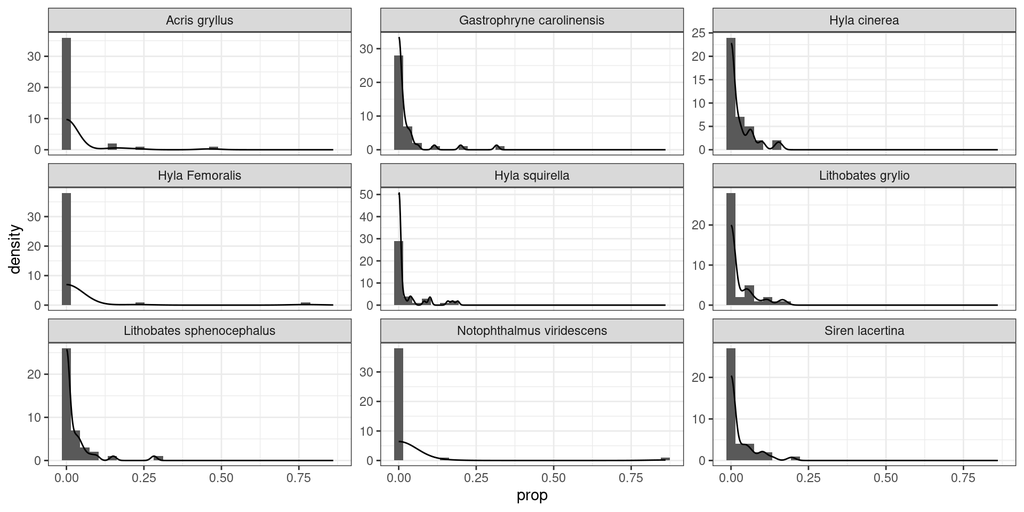

## Étape 4 - Xs: Pâturage

- La variable `cloture` est une variable catégorique à deux facteurs (Yes, No).
- La variable `vache_std` (Intensité d’utilisation de l’étang par le bétail) est une variable numérique continue dont la distribution [min ; max = 0 ; 0.6] est biaisée à gauche.
- 5 étangs sont clôturés ; 35 étangs ne l’étaient pas. Parmi ces derniers, 3 étangs ne semblent pas avoir été utilisés par les vaches (`vache_std`=0)

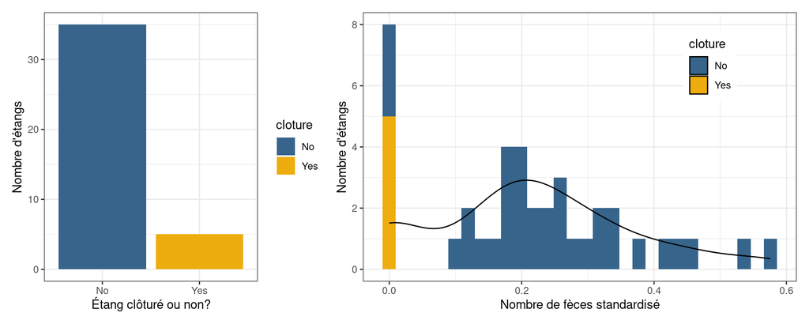

## Étape 4 - Xs : Caractéristiques physico-chimiques

- `conductivite`: numérique continue, distribution normale
- `nitrates` : numérique continue, distribution déviée à gauche
- `temperature` (Celcius): numérique continue, distribution déviée à gauche
  - Quelques valeurs extrêmes **-> on y reviendra!**

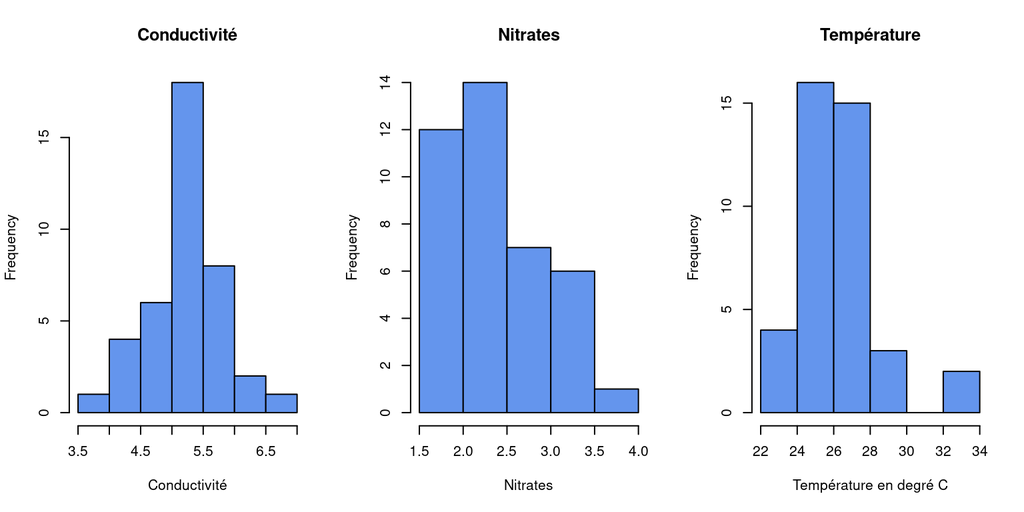

```
## [1]  1.38 11.88
```

## Étape 4 - Xs : Caractéristiques physico-chimiques

- Oxygène : numérique continue, distribution normale
  - Il y a des valeurs négatives!!! **-> on y reviendra!**
- pH : numérique continue, distribution déviée à gauche
  - Des étangs sont plus acides que du jus de citron, et presqu’aussi basiques que de l’eau de Javel! **-> on y reviendra!**

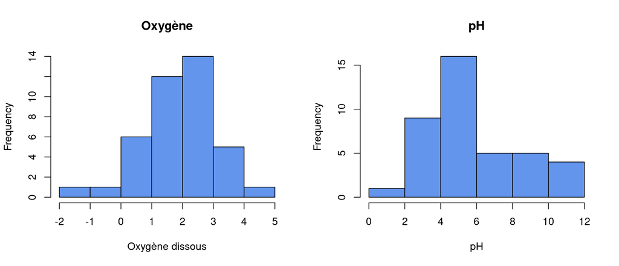

## Étape 4 - Xs : Facteurs biotiques

- Invertébrés : numérique continue, distribution déviée à gauche
- Écrevisses : numérique continue, distribution déviée à gauche avec beaucoup de zéros **-> on y reviendra!**
- Poissons : numérique continue, distribution avec beaucoup de zéros **-> on y reviendra!**

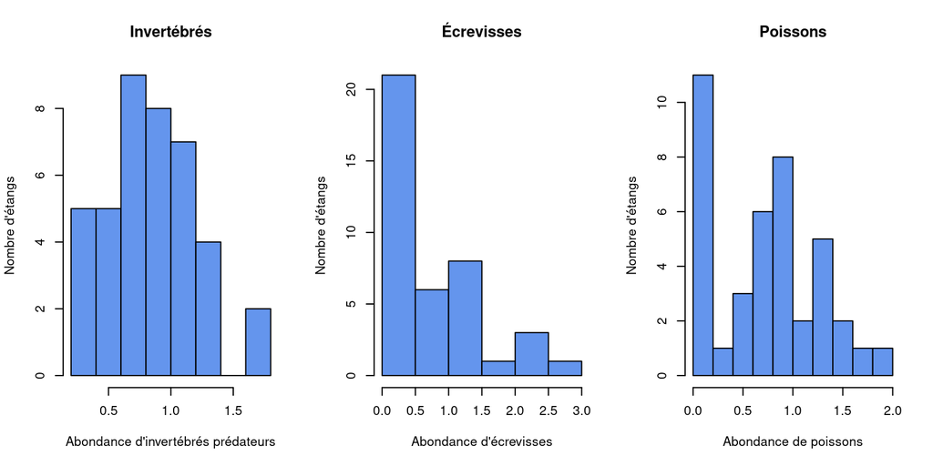

## Étape 4 - Xs en covariables : Caractéristiques topographiques

- Profondeur (cm) : numérique continue, distribution normale
- Aire (m²) : numérique continue, distribution *relativement* normale

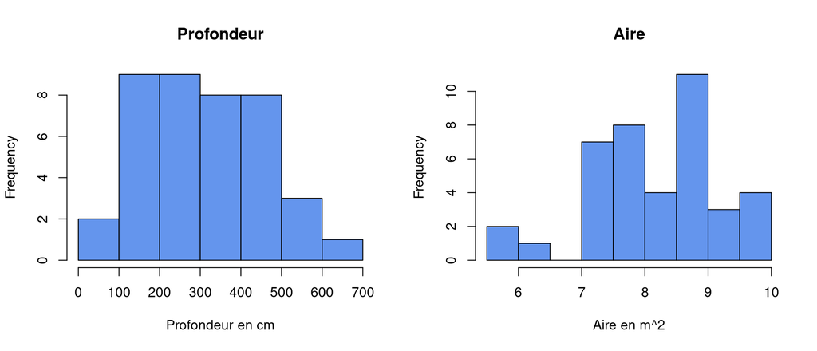

## Interactions potentielles à tester (étape 5)

Aucune.

## Étape 6. - Exploration des données

## 6.1 - Données aberrantes en X

- Les valeurs de vache_std sont entre 0 et 0.575
- Il ne semble pas y avoir de données aberrantes, mais 3 étangs non-clôturés ne semblent pas avoir été visités par les vaches.

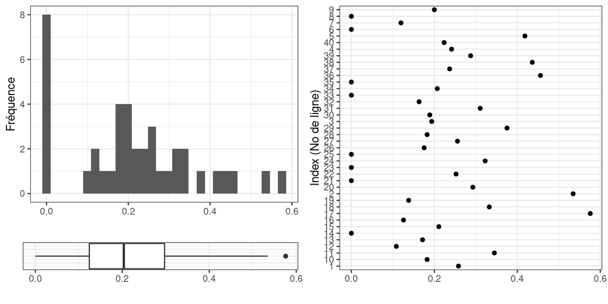

## 6.1 - Données aberrantes en X

- O² : Il y a des valeurs négatives!!!
- pH : Des étangs sont plus acides que du jus de citron, et presqu’aussi basiques que de l’eau de Javel!

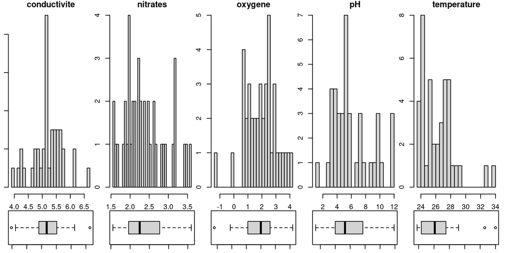

## 6.1 - Données aberrantes en X

Pas de données particulièrement aberrantes en ce qui concerne la topographie des étangs

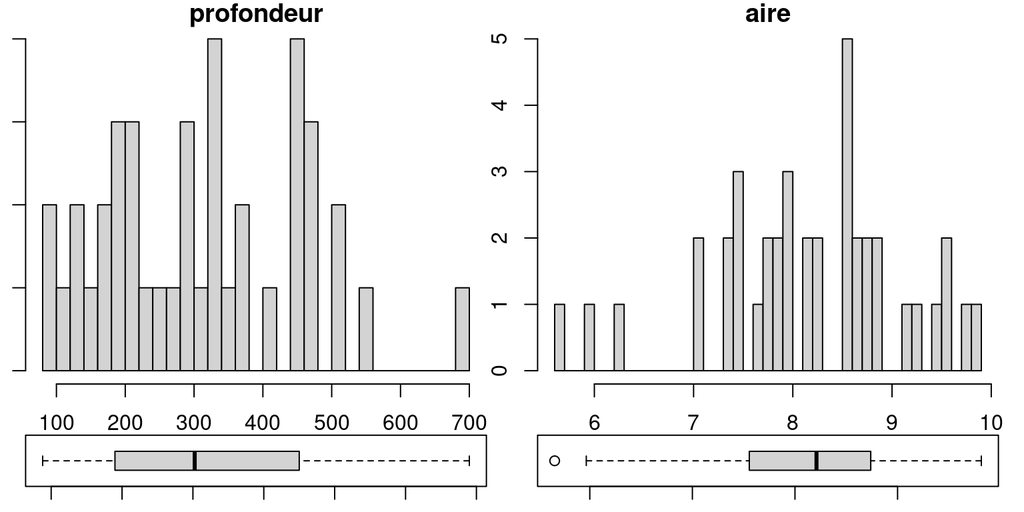

## 6.1 - Données aberrantes en X

- Poissons et les écrevisses: il semble y avoir beaucoup de zéros. Il faudra peut-être transformer.
  - On a tenté de le faire, sans grand succès, à la section “Matériel supplémentaire”.
- Les écrevisses étant des prédateurs des grenouilles (tétards), on pourrait peut-être travailler en absence-présence d’écrevisses dans nos analyses, si cette variable est problématique.
  - On a vérifié l’influence de travailler avec des variables binaires pour les comptes de poissons et d’écrevisses à la section “Matériel supplémentaire”.

*Pour la suite, nous travaillerons avec les données originales*, qu’on remet graphiquement ici:

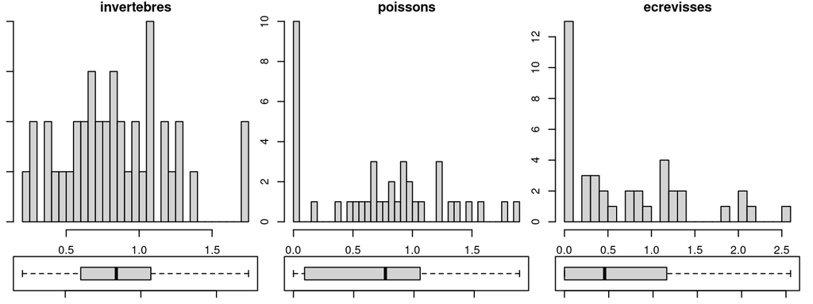

## 6.1 - Données aberrantes en Y

- On a déjà jeté un coup d’oeil à la distribution des abondances relatives d’amphibiens à l’étape 4. Le voici en rappel, mais seulement avec des boxplots.
- Pas vraiment de données aberrantes (beaucoup de 0, mais pas aberrant en soi), si ce n’est que quelques espèces rares.

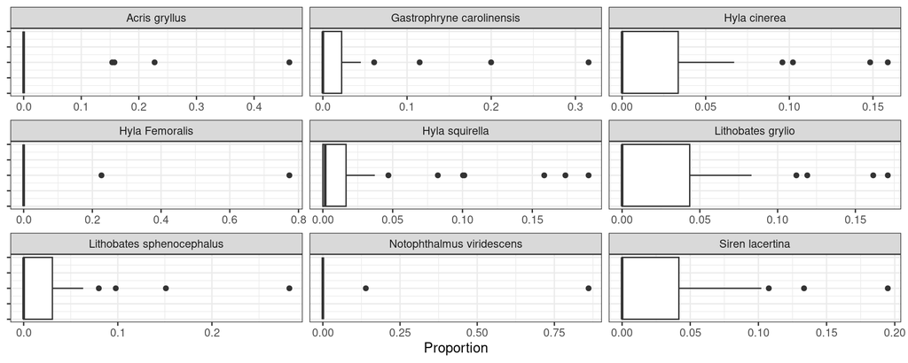

## 6.1 - Données aberrantes en Y

- On peut toutefois inspecter le nombre d’espèces à chaque site (convertir les abondances relatives en 0-1 pour chaque site). On peut aussi jetter un coup d’oeil à la richesse spécifique, avec le fait d’être clôturé ou pas (pourquoi pas?!).
- On peut voir quelles espèces sont rares dans notre jeu de données à gauche, et que les seuls sites mono-spécifiques sont aussi sans clôture, à droite.

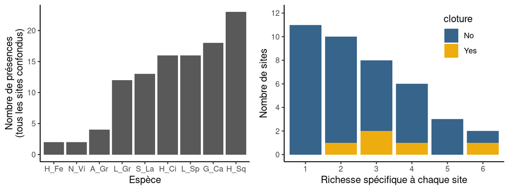

## 6.2 - Homogénéité de la variance et 6.3 - Normalité des Y

- Dans notre cas, on ne s’attend pas à ce que la variance des Ys soit homogène (on ne fait pas des modèles linéaires où les résidus devraient être homogènes, etc.); qui plus est, ce n’est pas une supposition à respecter dans le cadre d’une analyse multivariée (spoiler alert).
- Dans notre cas, on ne s’attend pas à ce que les Ys soient distribués normalement.

## 6.4 - Problèmes de 0 dans les Y

Comme on a vu plus tôt à l’étape 4 les zéros (absences) composent 70.5% de la matrice. Il se pourrait d’ailleurs que la faible présence de certaines espèces (H_Fe, N_Vi et A_GR) pose des problèmes pour l’analyse visée.

## 6.5 - Colinéarité des Xs

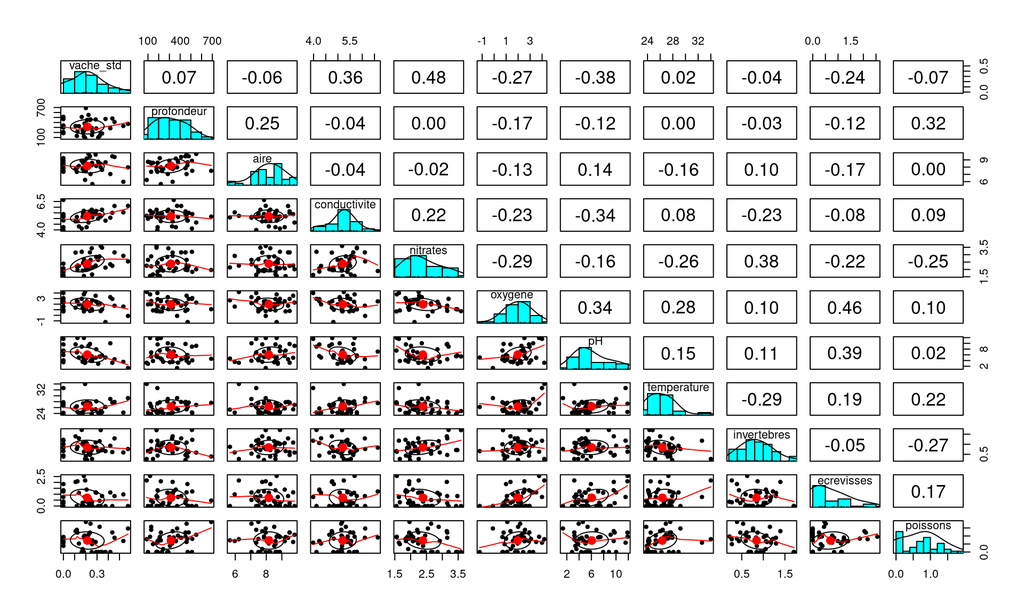

## 6.5 - Colinéarité des Xs

En ce qui concerne les variables numériques, on a quelques corrélations, mais rien de révoltant, surtout si on choisi une analyse qui n’est pas invalidée par ces colinéarités.

Peut-être un peu plus *d’intérêt* pour les corrélations avec `vache_std`:

- Corrélé positivement aux `nitrates` et à la `conductivite`,
- Corrélé négativement au `pH`

## 6.5 - Colinéarité des Xs

Variable cloture vs. variables *physico-chimiques* : rien d’alarmant, considérant qu’on a seulement 5 étangs clôturés. Semble y avoir une tendance entre le fait d’être clôturé et les nitrates.

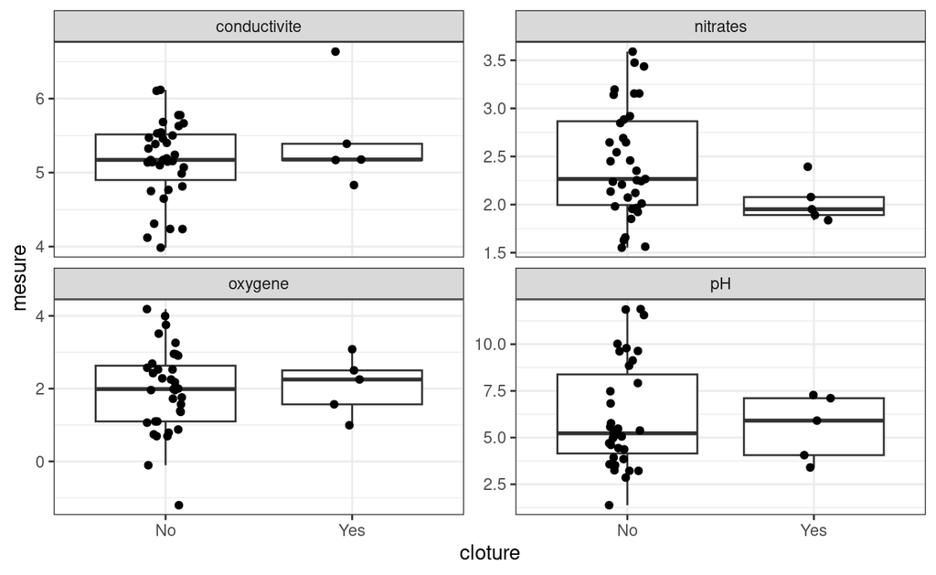

## 6.5 - Colinéarité des Xs

Variable cloture vs. variables *topographiques* : rien d’alarmant, considérant qu’on a seulement 5 étangs clôturés.

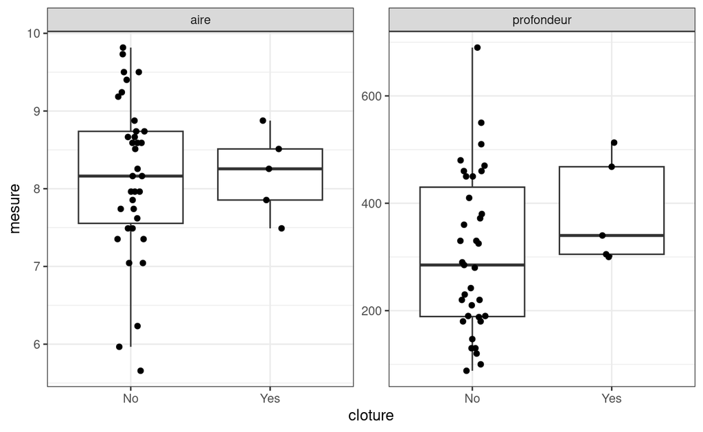

## 6.5 - Colinéarité des Xs

Variable clôture vs. variables *biotiques*

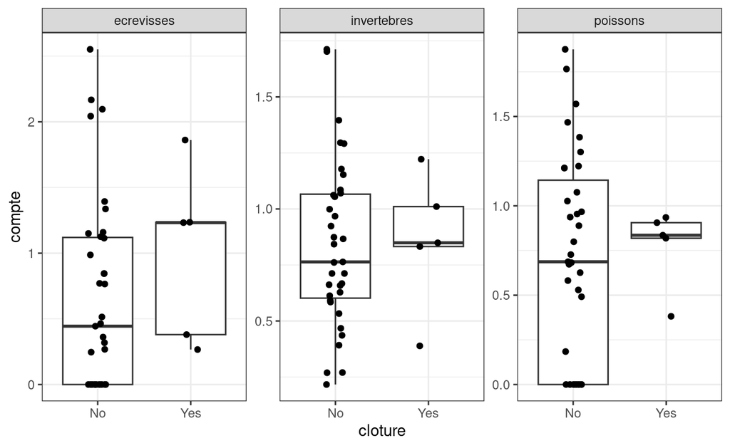

## 6.6 - Liens X et Y

Abondances relatives en fonction des paramètres physico-chimiques

> Ligne + interval = smooth (‘loess’; ‘y ~ x’).

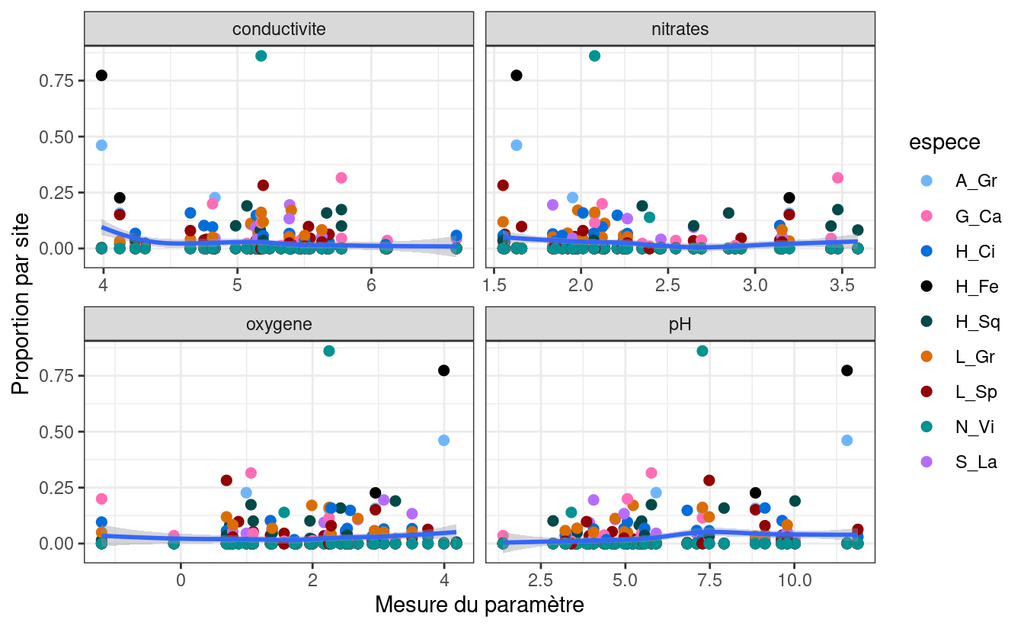

## 6.6 - Liens X et Y

Abondances relatives en fonction des caractéristiques topographiques

> Ligne + interval = smooth (‘loess’; ‘y ~ x’).

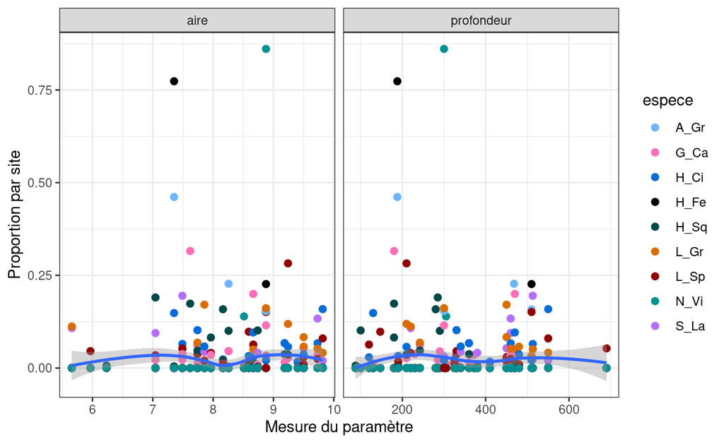

## 6.6 - Liens X et Y

Abondances relatives en fonction des facteurs biotiques

> Ligne + interval = smooth (‘loess’; ‘y ~ x’).

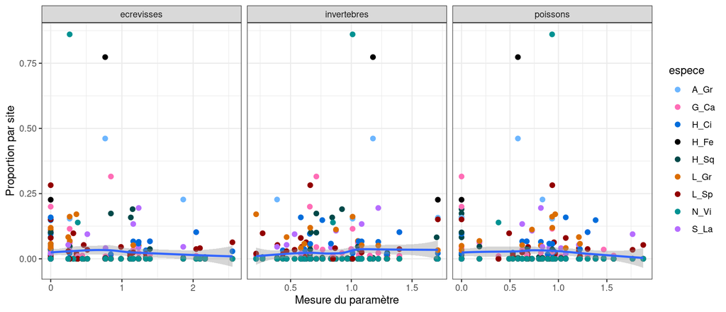

## 6.6 - Liens X et Y

Abondances relatives en fonction de l’intensité des vaches et de la présence de cloture.

> Ligne + interval = smooth (‘loess’; ‘y ~ x’).

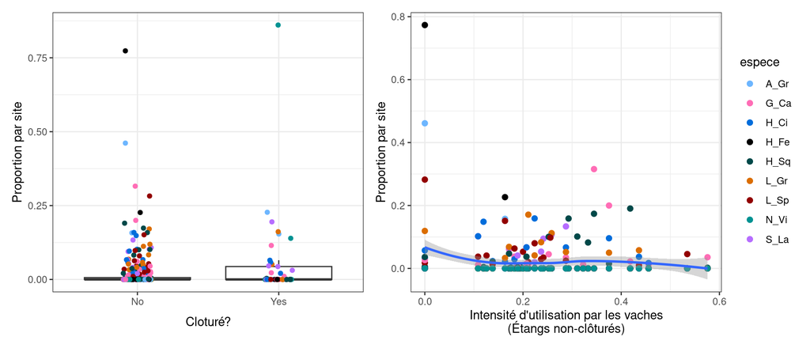

## 6.7 - Indépendance des Y

Richesse spécifique à chaque site:

- Les données semblent indépendantes.

Plus ou moins pour vérifier l’indépendance des sites, les étangs avec plus d’espèces semblent être plus creux et plus gros.

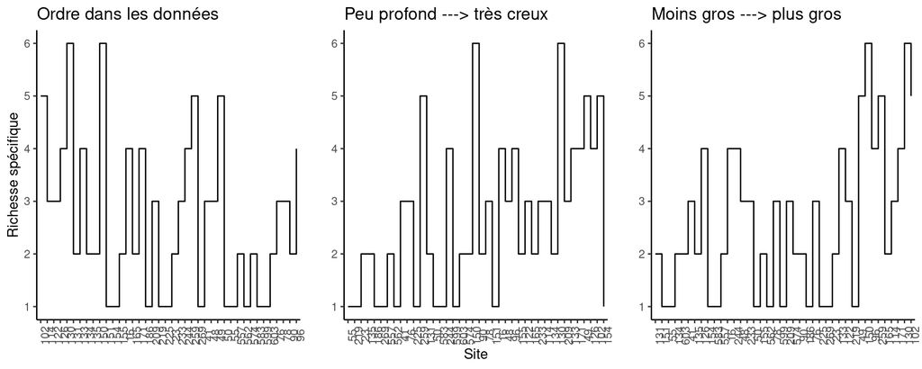

## 6.8 - Colinéarité des Y

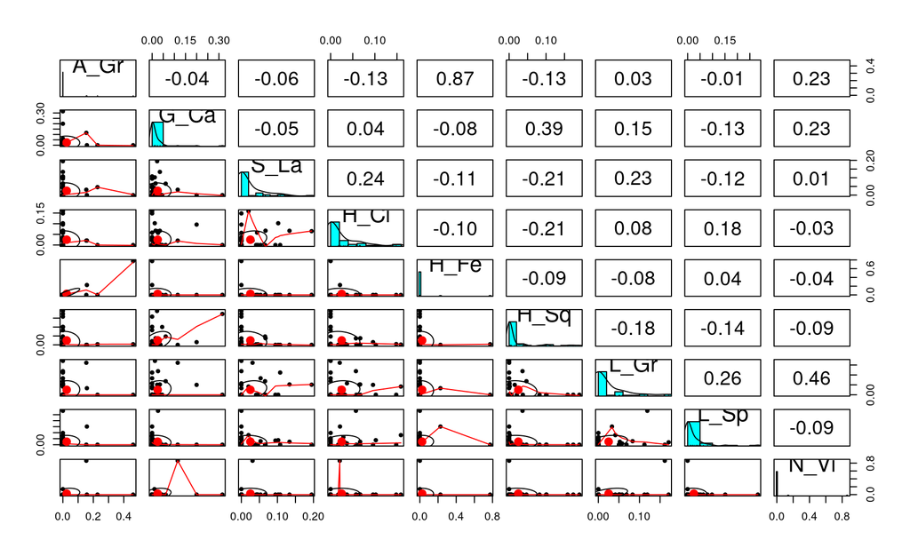

## Faits saillants de l’exploration (étape 6):

- Les données d’abondance ont été standardisées par unité d’effort et par abondance totale pour chaque espèce (somme pour chaque espèce est égale à 1).
  - Près de 71% des données de la matrice d’abondance sont égales à 0.
- Les variables physico-chimiques devront être standardisées
  - Certaines variables physico-chimiques semblent avoir des mesures erronnées.
  - L’oxygène et le pH sont plus problématique. On va ignorer les valeurs de pH, et retirer les sites d’O² négatif.
  - On a vérifié les valeurs extrêmes de temperature (section matériel supplémentaire), rien à signaler. La transformation log ne colle pas particulièrement les valeurs extrêmes au reste des données.
- La transformation log des poissons ou des écrevisses n’atténue pas la sureprésentation des zéros vus dans la distribution des données brutes.
- La topographie des étangs pourrait influencer d’autres facteurs physico-chimiques, et donc l’aire et la profondeur devraient être considérées comme des covariables.
  - Les étangs plus creux et plus grands semblent avoir une richesse spécifique supérieure.

## Étape 7. Choix de l’analyse

**Pourquoi une analyse multivariée?**

- Analyse de données complexes en terme de dimensionalité : plusieurs variables avec plusieurs dimensions de manière simultanée

**Quelle analyse multivariée?**

- Nous avons décidé d’utiliser une analyse de redondance (RDA) partielle

**Pourquoi pas MANOVA? Pourquoi pas PCA/analyse non-contrainte?**

- MANOVA : test paramétrique donc requiert une distribution normale multivariée dans les abondances d’espèces, ce qui est rarement le cas en pratique. Elle utilise les distances euclidiennes qui ne sont pas appropriées pour les abondances d’espèces et aussi il y a souvent plus d’espèces que de degrés de libertés dans le système.
- ANC : analyse multivariée mais pas un test statistique donc c’est purement descriptif

## Étape 7. Choix de l’analyse

**Pourquoi?**

- Appropriée pour mettre en lien des variables liées aux espèces (matrice Y) et des variables environnementales (matrice X) comme dans notre cas.
- Test non paramétrique donc pas besoin de supposer une distribution normale multivariée : la majorité de nos variables dans la RDA partielle ne sont pas distribuées de manière normale.
- RDA partielle parce qu’on a des covariables (topographie) qui ne nous intéressent pas mais qui vont influencer les relations entre les autres variables.
- Combine une régression linéaire multiple à une ordination classique (PCA).

## Étape 7. Choix de transformation de la matrice d’abondance:

Communauté d’amphibiens :

- Problème de double zéros
- Données standardisées par abondance totale d’espèce Transformation nécessaire: mesure de **dissimilarité assymétrique**. Nous avons 2 options:
1. Utiliser les données d’abondance standardisées et les transformer
2. Utiliser les données de présence-absence (binaire) et les transformer

Nous choisissons la 1ère option.

- On conserve davantage d’informations sur les co-fluctuations des abondances et ça respecte l’idée des investigateurs de donner davantage de poids aux espèces rares dans l’analyse de la communauté amphibienne de ces étangs.
- Nous utiliserons la transformation de Hellinger, recommandée par de nombreux auteurs pour l’ordination des données d’abondance d’espèces (Legendre et Legendre, 2012) et qui obtient le meilleur R² pour représenter la distance géographique réelle (Legendre et Gallagher, 2001).

## Étape 8.0 Exécuter l’analyse

A- On commence par transformer les matrices d’abondance.

```r
library("vegan")
#library(adespatial)
# Faire une matrice de distance Hellinger

# Alternate, two-step computation in vegan:
amphi.hel= dat%>%
    subset(oxygene>0) %>%
  # on enlève les sites avec l'oxygène à 0 ^^
  select(A_Gr:N_Vi) %>%
  decostand("hellinger")
rownames(amphi.hel) <- subset(dat, oxygene>0)$etang
# On change le nom des lignes pour se retrouver plus tard ^^

head(amphi.hel) %>% round(digits = 2)
```

```
##     A_Gr G_Ca S_La H_Ci H_Fe H_Sq L_Gr L_Sp N_Vi
## 131 0.00 0.00 0.70    0 0.00 0.00 0.71 0.00    0
## 151 0.00 0.00 0.00    0 0.00 0.00 0.00 1.00    0
## 55  0.00 0.00 0.00    0 0.00 1.00 0.00 0.00    0
## 134 0.00 0.00 0.86    0 0.00 0.00 0.00 0.52    0
## 603 0.00 0.32 0.00    0 0.00 0.95 0.00 0.00    0
## 41  0.61 0.00 0.00    0 0.79 0.05 0.00 0.00    0
```

## Étape 8.0 Exécuter l’analyse

B- On standardise les covariables.

```r
# Co-variables
topo=dat %>%
    subset(oxygene>0) %>%
  select(aire, profondeur) %>%
  decostand("standardize")

rownames(topo) <- subset(dat, oxygene>0)$etang
# On change le nom des lignes pour se retrouver plus tard ^^
head(topo) %>% round(digits = 2)
```

```
##      aire profondeur
## 131 -2.52      -0.61
## 151 -2.21       0.15
## 55  -1.94      -1.52
## 134 -1.12       1.04
## 603 -1.12      -0.16
## 41  -0.81      -0.83
```

## Étape 8.0 Exécuter l’analyse

C- Les variables.

```r
env=dat %>%
  select( vache_std, conductivite:temperature, invertebres:poissons) %>%
  select(-pH) %>% # on enlève ceci. pas assez fiable.
  subset(oxygene>0) %>% # erreurs de mesure. pas assez fiable.
  decostand("standardize") %>%
  mutate(cloture=dat[dat$oxygene>0,]$cloture) %>% data.frame()
# on rattache la variable cloture, qui n'est pas standardisée (catégorique)^^
rownames(env) <- subset(dat, oxygene>0)$etang
# On change le nom des lignes pour se retrouver plus tard ^^
glimpse(env)
```

```
## Rows: 38
## Columns: 9
## $ vache_std    <dbl> 0.421737872, 2.397886862, -0.039894332, 0.302478603, 1.56…
## $ conductivite <dbl> -0.15650285, 0.65800719, 0.10220752, -0.08833039, -0.2099…
## $ nitrates     <dbl> -0.44404172, 0.93996623, -0.23566489, 0.45767891, -0.0627…
## $ oxygene      <dbl> 0.60852236, -0.56605218, 2.17980880, 0.07005539, 1.206968…
## $ temperature  <dbl> -0.43305850, -0.87306445, 3.39499334, 0.27095104, 1.15096…
## $ invertebres  <dbl> 0.065236700, -0.701053563, -1.574598528, -0.858598067, 0.…
## $ ecrevisses   <dbl> -1.0132385, 0.3466874, 1.9735408, -0.3044406, 0.5716819, …
## $ poissons     <dbl> 0.01891147, -0.05682433, 0.15465839, 1.97981137, -1.35405…
## $ cloture      <fct> No, No, No, No, No, No, No, Yes, No, No, No, No, No, Yes,…
```

## RDA partielle

### modèle global

## Étape 8.1 Exécuter l’analyse

On lance la RDA partielle:

```r
require(vegan)
(prda=rda(amphi.hel~ . + Condition(topo$aire +topo$profondeur), env) )
```

```
## Call: rda(formula = amphi.hel ~ vache_std + conductivite + nitrates +
## oxygene + temperature + invertebres + ecrevisses + poissons + cloture +
## Condition(topo$aire + topo$profondeur), data = env)
##
##               Inertia Proportion Rank
## Total         0.71718    1.00000
## Conditional   0.06892    0.09610    2
## Constrained   0.24587    0.34283    9
## Unconstrained 0.40239    0.56107    9
## Inertia is variance
##
## Eigenvalues for constrained axes:
##    RDA1    RDA2    RDA3    RDA4    RDA5    RDA6    RDA7    RDA8    RDA9
## 0.10093 0.05873 0.03421 0.02333 0.02052 0.00539 0.00183 0.00061 0.00034
##
## Eigenvalues for unconstrained axes:
##     PC1     PC2     PC3     PC4     PC5     PC6     PC7     PC8     PC9
## 0.11000 0.09078 0.06506 0.05788 0.03730 0.02527 0.00973 0.00405 0.00232
```

## Étape 8.1 Exécuter l’analyse

- Près de 10% de la variance dans l’abondance est expliquée par les covariables,
- ~34% par les variables environnementales.

Avec un R² ajusté, la variation expliquée par les variables environnementales tombe à :

```r
 (R2adj <- round(RsquareAdj(prda)$adj.r.squared, dig=3))
```

```
## [1] 0.157
```

Plus modeste! Aussi, ça concorde un peu plus avec la comparaison des premières valeurs propres de la RDA et de la PCA sur la variation résiduelle, qui sont pas mal similaires.

## Étape 8.2 Valider l’analyse

Le test de permutations du modèle global nous indique que le modèle a quand même une certaine valeur, il permet d’expliquer une proportion de la variance dans les communautés d’abondances :

```r
anova(prda, permutations = how(nperm = 999))
```

```
## Permutation test for rda under reduced model
## Permutation: free
## Number of permutations: 999
##
## Model: rda(formula = amphi.hel ~ vache_std + conductivite + nitrates + oxygene + temperature + invertebres + ecrevisses + poissons + cloture + Condition(topo$aire + topo$profondeur), data = env)
##          Df Variance      F Pr(>F)
## Model     9  0.24587 1.7652  0.004 **
## Residual 26  0.40239
## ---
## Signif. codes:  0 '***' 0.001 '**' 0.01 '*' 0.05 '.' 0.1 ' ' 1
```

## Étape 8.2 Valider l’analyse

Le test de permutations sur les axes nous indique que seulement le premier axe de la RDA est *significatif*

```r
anova(prda, by="axis", permutations = how(nperm = 999))
```

```
## Permutation test for rda under reduced model
## Forward tests for axes
## Permutation: free
## Number of permutations: 999
##
## Model: rda(formula = amphi.hel ~ vache_std + conductivite + nitrates + oxygene + temperature + invertebres + ecrevisses + poissons + cloture + Condition(topo$aire + topo$profondeur), data = env)
##          Df Variance      F Pr(>F)
## RDA1      1  0.10093 6.5215  0.006 **
## RDA2      1  0.05873 3.7948  0.215
## RDA3      1  0.03421 2.2101  0.852
## RDA4      1  0.02333 1.5071  0.972
## RDA5      1  0.02052 1.3259  0.960
## RDA6      1  0.00539 0.3480  1.000
## RDA7      1  0.00183 0.1184  1.000
## RDA8      1  0.00061 0.0391  1.000
## RDA9      1  0.00034 0.0217  1.000
## Residual 26  0.40239
## ---
## Signif. codes:  0 '***' 0.001 '**' 0.01 '*' 0.05 '.' 0.1 ' ' 1
```

## Étape 8.2 Valider l’analyse

Le tests de permutations sur les variables explicatives montre que les variables `cloture`, `nitrates`, `vache_std` et `poissons` semblent mieux expliquer la variance dans la matrice d’abondances des amphibiens. C’est aussi envisageable de réduire le nombre de variables dans la RDA dans de prochaines étapes.

```r
anova(prda, by="term", permutations = how(nperm = 999))
```

```
## Permutation test for rda under reduced model
## Terms added sequentially (first to last)
## Permutation: free
## Number of permutations: 999
##
## Model: rda(formula = amphi.hel ~ vache_std + conductivite + nitrates + oxygene + temperature + invertebres + ecrevisses + poissons + cloture + Condition(topo$aire + topo$profondeur), data = env)
##              Df Variance      F Pr(>F)
## vache_std     1  0.02915 1.8834  0.071 .
## conductivite  1  0.01786 1.1541  0.340
## nitrates      1  0.03546 2.2914  0.032 *
## oxygene       1  0.02371 1.5319  0.146
## temperature   1  0.02038 1.3166  0.235
## invertebres   1  0.01364 0.8812  0.526
## ecrevisses    1  0.02580 1.6672  0.127
## poissons      1  0.04752 3.0706  0.002 **
## cloture       1  0.03235 2.0906  0.039 *
## Residual     26  0.40239
## ---
## Signif. codes:  0 '***' 0.001 '**' 0.01 '*' 0.05 '.' 0.1 ' ' 1
```

## Étape 8.2 Valider l’analyse

Vérifier s’il y a de la colinéarité entre les variables explicatives:

```r
vif.cca(prda)
```

```
##       topo$aire topo$profondeur       vache_std    conductivite        nitrates
##        1.161290        1.553501        3.018691        1.853021        2.356586
##         oxygene     temperature     invertebres      ecrevisses        poissons
##        1.938537        1.485461        1.705105        1.330484        1.459520
##      clotureYes
##        2.426818
```

Tout est bien.  
Jettons un coup d’oeil aux triplots maintenant.

## Étape 8.3 - Interpréter les résultats : triplots

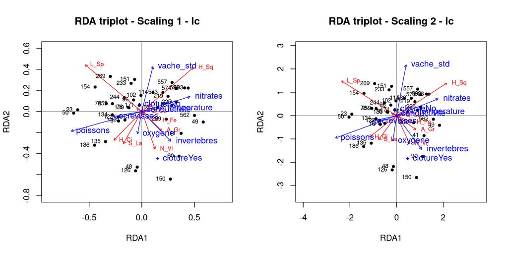

## 8.3 - Interpréter les résultats : triplots

- Différences dans la communauté d’amphibiens entre les étangs clôturés et non clôturés
  - Des espèces d’amphibiens *rares* dans notre système sont favorisées par la présence de clôture
  - N_Vi
  - A_Gr
- L’intensité d’utilisation des étangs par les vaches tend à influencer la communauté d’amphibiens
  - Plus c’est utilisé par les vaches, plus il y a de nitrates
    - L’espèce H_Sq et les nitrates sont corrélés positivement.
- Plus il y a de nitrates, moins il y a de poissons.
- Certains amphibiens sont retrouvés là où il y a plus de poissons:
  - H_Ci
  - S_La

## 8.3 - Partitionner la variance du modèle global

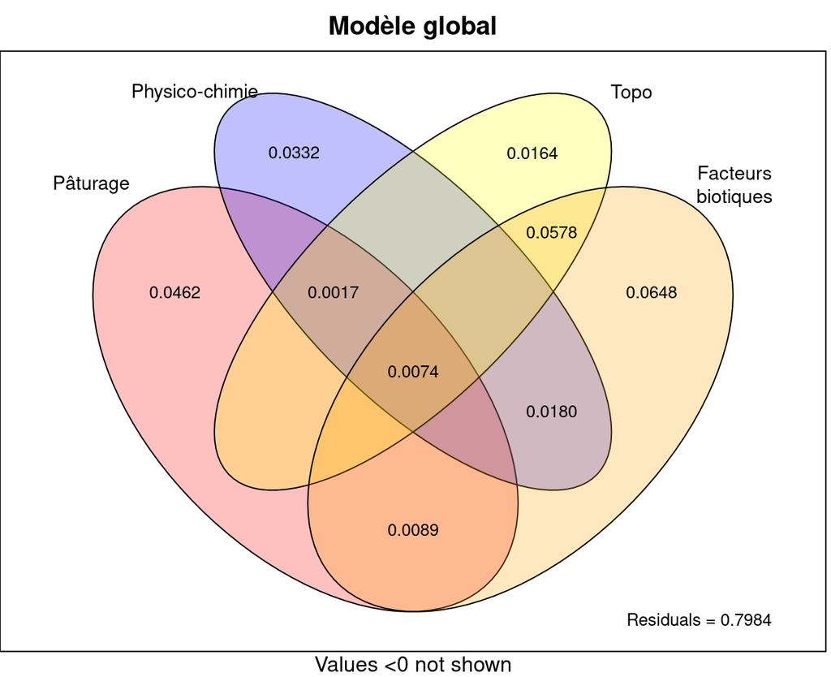

## 8.3 - Interpréter les résultats : Partitionner la variance

- Les facteurs biotiques combinés aux variables reliées au pâturage par les vaches expliquent la majorité de la petite portion de variance expliquée par notre analyse de redondance.
  - Le fait d’être clôturé et l’intensité d’utilisation par les vaches expliquent 4.6% de la variance,
  - Les facteurs biotiques expliquent 6.5%,
  - Combinés, ces facteurs expliquent 12% de la variance dans la matrice d’abondances d’amphibiens.

## FIN

Ils vécurent heureux et eurent beaucoup de tétards

## Matériel supplémentaire

### Effet de quelques variables moins disciplinées

On a voulu vérifier la validité de valeurs plus élevées ou plus basses pour le pH et la température.

Ensuite, on épargne le code un peu, pour des raisons visuelles (disponible dans le `.Rmd`), mais on a testé différentes transformations (plusieurs saveurs de log, et aussi la racine carré) sur la température, les poissons et les ecrevisses.

- Visuellement, ce n’était pas très concluant. On a gardé la valeur de température sur son échelle originale.
- Par contre, on a modélisé les poissons et écrevisses comme des valeurs binaires, question de vérifier si les conclusions variaient beaucoup entre deux modèles globaux.

## Matériel supplémentaire - RDA avec variables binaires

On lance la RDA partielle, avec des variables binaires pour les poissons et les écrevisses. `env2` a été fait plus haut mais le code est caché (voir fichier `.Rmd`).

```r
require(vegan)
(prda2=rda(amphi.hel ~ . + Condition(topo$aire +topo$profondeur), env2) )
```

[output not shown]

## Matériel supplémentaire - RDA checks

```r
(R2adj_2 <- round(RsquareAdj(prda2)$adj.r.squared, dig=3))

anova(prda2, permutations = how(nperm = 999))
anova(prda2, by="axis", permutations = how(nperm = 999))
anova(prda2, by="term", permutations = how(nperm = 999))
vif.cca(prda2)
```

[output not shown]

## Matériel supplémentaire

### Selection backward de variables

En faisant la selection **backward** de la RDA partielle (modèle global), ces variables sont celles qui ressortent:

```r
step.back<- ordistep(prda, permutations = how(nperm=499))
step.back$terminfo$terms %>% attr(., "variables")

# list(nitrates, temperature, poissons, cloture, topo$aire, topo$profondeur)
```

avec un R² ajusté de

```
## [1] 0.1412477
```

et le test de permutations sur les variables enlevées à l’air de ceci:

```
##                Df     AIC      F Pr(>F)
## - vache_std     1 -13.152 0.3126  0.944
## - oxygene       1 -14.071 0.7790  0.606
## - conductivite  1 -13.962 1.5978  0.150
## - ecrevisses    1 -14.088 1.4665  0.162
## - invertebres   1 -14.175 1.5487  0.148
```

## Matériel supplémentaire

### Faire une RDA basée sur le stepwise

```r
(rda.parci2b=rda(amphi.hel ~ temperature + nitrates+ cloture + poissons + Condition(topo$aire +topo$profondeur), env3) )
```

[output not shown]

```r
set.seed(1)
anova(rda.parci2b, permutations = how(nperm = 999))
anova(rda.parci2b, by="axis", permutations = how(nperm = 999))
anova(rda.parci2b, by="terms", permutations = how(nperm = 999))

round(RsquareAdj(rda.parci2b)$adj.r.squared, dig=3)
vif.cca(rda.parci2b)
```

[output not shown]

## Matériel supplémentaire

### Faire une RDA basée sur le stepwise

Le partitionnement de la variance pour ce modèle :

```r
cloture<-env[,1]
poiss=env$poissons
physico=env[,c("temperature", "nitrates")]

amphi.parsi <- varpart(amphi.hel, cloture, physico, poiss, topo)
par(mar=c(1,.2,2,0))

plot(amphi.parsi,
     digits=3, bg = c("red",
                      "orange",
                      "yellow",
                      "blue"),
     Xnames = c("Clôture","Physico-chimie", "Poissons", "Topo"),
     id.size=0.9, cex=.8)+
  title("Modèle le plus parsimonieux")
```

[output not shown]